# 2016 Ocean Health Index Global Assessment: Colombia Profile

This document provides a brief summary of the results for Colombia from the 2016 Ocean Health Index (OHI) Global Assessment.

## Global results

As in previous years, this assessment updated datasets and methods to integrate new knowledge and information. The Index Global score for 2016, the Exclusive Economic Zone (EEZ) area weighted average of region (countries and territories) scores was 71. This value did not vary statistically significantly from 2012 to 2016.

## Global Flower Plot

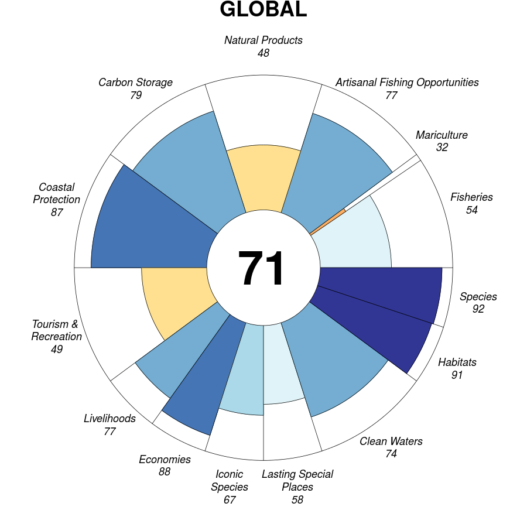

Global Flower Plot

Several goals had significant changes:

### Improving scores

- Lasting special places scores increased by an average of 0.5 points per year
- Artisanal opportunities scores increased by just over 0.15 points per year
- Species condition scores improved by a small, but statistically significant, 0.03 points per year ### Declining scores
- Natural products declined by over 2.5 points per year on average
- Coastal protection declined by 0.12 points per year on average
- Clean waters declined by 0.15 points per year on average
- Species condition was ranked the goal with the highest score of 92, while mariculture was ranked the goal with the lowest score of 32.

For a detailed summary of global results visit: http://www.oceanhealthindex.org/region-scores

## Methods and dataset updates

Additional years of data were available for the following goals/subgoals: artisanal opportunities, species condition, habitat and coastal protection (sea ice), mariculture, clean waters (land-based pollution), iconic species, lasting special places, natural products, tourism and recreation.

Improved data were available for the following goals/subgoals: fisheries, species condition (bird data are now included), clean waters (trash trends are calculated using actual trash data, rather than proxy population data), iconic species (trend is now directly estimated from data).

**Pressures:** Of the pressures data sets, 16 of the 20 pressure data layers were updated. Additional years of data for 7 pressures layers were added, and there were major improvements to source data for fisheries related pressures and sea level rise. Data from the Social Progress Index (http://www.socialprogressimperative.org/global-index/) was included as a “social” component of the pressure scores. Resilience: We restructured the resilience data within the OHI, so the data and calculations are more transparent and easier to understand and update. Data from the Social Progress Index (http://www.socialprogressimperative.org/global-index/) was added as a “social” component of resilience scores. Only two resilience data layers were updated: species condition and marine protected areas.

For detailed explanation of methods visit: http://www.oceanhealthindex.org/methodology

## Colombia Results

The 2016 Index score for Colombia is of 60. Ranking 178 among all countries.

## Table showing 2012-2016 scores

[output not shown]

## Colombia Flower plot

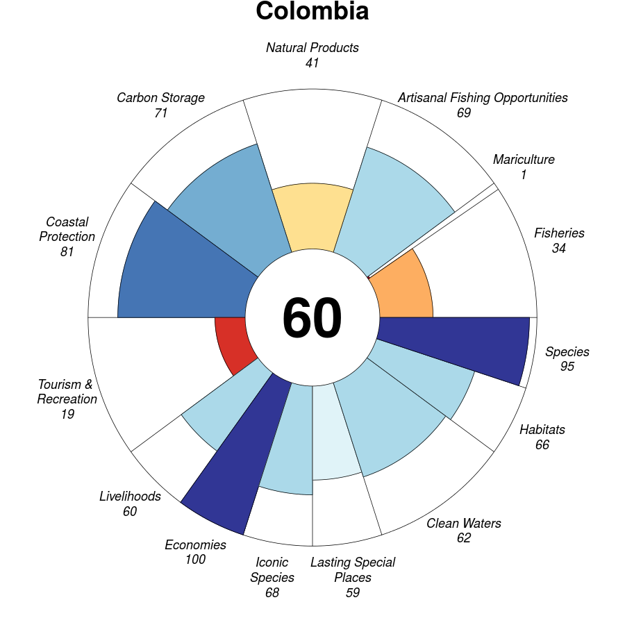

Colombia Flower Plot

## Explanation of the scores

For a detailed summary of Country results visit: http://www.oceanhealthindex.org/region-scores/scores/Colombia